| “Factors of the Cost of Housing” |
| --- |
| By Prescott Massingill |

Cost of living across off america has been hotly studied topic for a long time. This is because its understood that a greater understanding of the differences between systematic variations of cost of living helps policy makers craft proposals that are more effective. This is partticularly relevent with the main stream discussions of Universal Basic Income and Minimum Wage increases. These types of proposals effect people accross the crountry and the real impact of those types of transfers are determined by the cost of living in those area. There for further understanding how the effects of cost of living will create strong foundations as to means test these programs.

The first Paper that is helping inform the research for the following anaylsis is “Determinants of Metropolittan Cost of Living Variations” writen by C. T. Haworth and D. W Rasmussen. This paper was writen in 1973 showing the depth of intrest for this topic through time and how we are still wressling with this topic to this day. The factors that this paper focused on was economies or diseconomies of scale in provision of public services, externalities affecting the compensation of tthoes employed in the city, and the cost of land. A reaccuring theme throughout the papers on the cost of living was the cost of land which is where the following analysis will start. The second Paper that helps guide this anaylsis is “Housing Demand, Cost-of-Living Inequality, and the Affordability Crsis” by David Albouy, Babriel Ehrlich, and Yingyi Liu. This paper demonstrates how Cost of living indexs deomonstrate that the poor are more heavily impacted by the relative increases to rent. This has led to real income inequality due to higher amounts of nominal income going toward housing. The regression used in this anaylsis will explain how the factors to the cost of housing effect different groups differently.

This project will be analyzing the different factors that impact the cost of housing. Since there are many impacts I will narrow the scope of my analysis to several factors and narrow the geographical area in question. the American Community Survey data from the Census Bureau is used for this anaysis.

```r
library("ggplot2")
library(tidycensus)
library(tidyverse)
library(viridis)
#census_api_key("251f3a6133e1e608c5b54d57d3b90611e6d7d102",install = TRUE)
```

To get a broud picture of what the housing costs are like in America. First take the housing costs by state across america to get the big picture and get an expected range. These costs will be monthly housing costs

```r
v2 <- load_variables(year = "2018",
                     dataset = "acs5",
                     cache = TRUE)
```

```r
B25104 <- filter(v2, str_detect(name, "B25104"))

head(B25104)
```

```
## # A tibble: 6 x 3
##   name       label                           concept
##   <chr>      <chr>                           <chr>
## 1 B25104_001 Estimate!!Total                 MONTHLY HOUSING COSTS
## 2 B25104_002 Estimate!!Total!!Less than $100 MONTHLY HOUSING COSTS
## 3 B25104_003 Estimate!!Total!!$100 to $199   MONTHLY HOUSING COSTS
## 4 B25104_004 Estimate!!Total!!$200 to $299   MONTHLY HOUSING COSTS
## 5 B25104_005 Estimate!!Total!!$300 to $399   MONTHLY HOUSING COSTS
## 6 B25104_006 Estimate!!Total!!$400 to $499   MONTHLY HOUSING COSTS
```

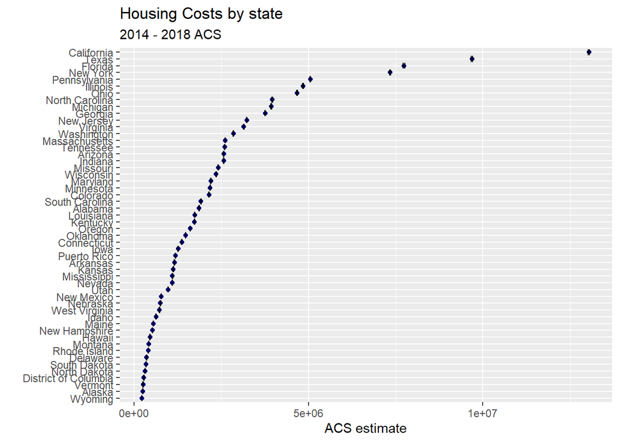

```r
Hcost_state <- get_acs(geography = "state",
                     variables = c(HousingCost = "B25104_001"),
                    output = "wide"
                     )
ggplot(Hcost_state, aes(x = HousingCostE, y = reorder(NAME, HousingCostE))) +
  labs(x = "ACS estimate",
       y = "",
       title = "Housing Costs by state",
       subtitle = "2014 - 2018 ACS") +
  geom_point(color = "navy") +
  geom_errorbarh(aes(xmin = HousingCostE - HousingCostM, xmax = HousingCostE + HousingCostM))
```

```r
v3 <- load_variables(year = "2019",
                     dataset = "acs1",
                     cache = TRUE)
```

```r
B25106 <- filter(v3, str_detect(name, "B25106"))
```

```r
state_Costs <- get_acs(geography = "state",
                     variables =  c(HousingCost = "B25106_001"),
                     survey = "acs1",
                     output = "wide"
                     )
```

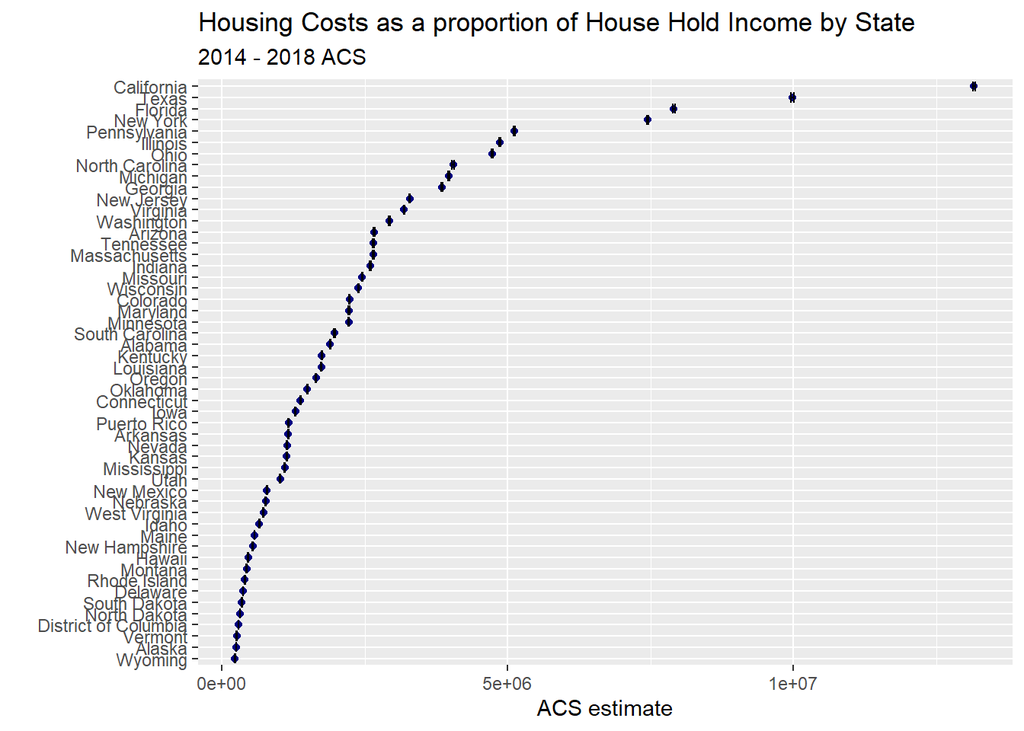

```r
ggplot(state_Costs, aes(x = HousingCostE, y = reorder(NAME, HousingCostE))) +
  geom_point(color = "navy") +
  geom_errorbarh(aes(xmin = HousingCostE - HousingCostM, xmax = HousingCostE + HousingCostM)) +
  labs(x = "ACS estimate",
       y = "",
       title = "Housing Costs as a proportion of House Hold Income by State",
       subtitle = "2014 - 2018 ACS")
```

Next lets narrow the view more to a singular state and its said counties. There will still be a rural and urban divide that will be shown much like the state graph. This more narrow state/county view will isolate factors that might get effected with large geographical difference.

```r
county_costs <- get_acs(geography = "county",
                     variables =  c(HousingCost = "B25106_001"),
                     survey = "acs5",
                     output = "wide",
                     state = "New York",
                     )
```

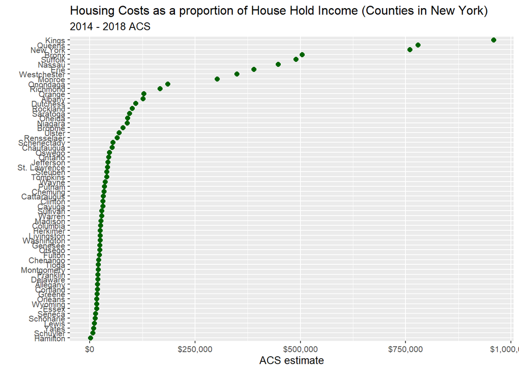

```r
county_costs2 <- county_costs %>%
  mutate(NAME = str_replace(NAME, " County, New York", ""))



ggplot(county_costs2, aes(x = HousingCostE, y = reorder(NAME, HousingCostE))) +
  geom_point(size = 2, color = "darkgreen") +
  theme_grey(base_size = 10) +
  labs(title = "Housing Costs as a proportion of House Hold Income (Counties in New York)",
       subtitle = "2014 - 2018 ACS",
       x = "ACS estimate",
       y = "") +
  scale_x_continuous(labels = scales::dollar)
```

This view gives a simmilar view to the state view where there is a visable curve into the extremes of true housing costs in specific areas.

The housing cost as a proportion of income will be refered to as the real housing costs for the remainder of this anaylsis.

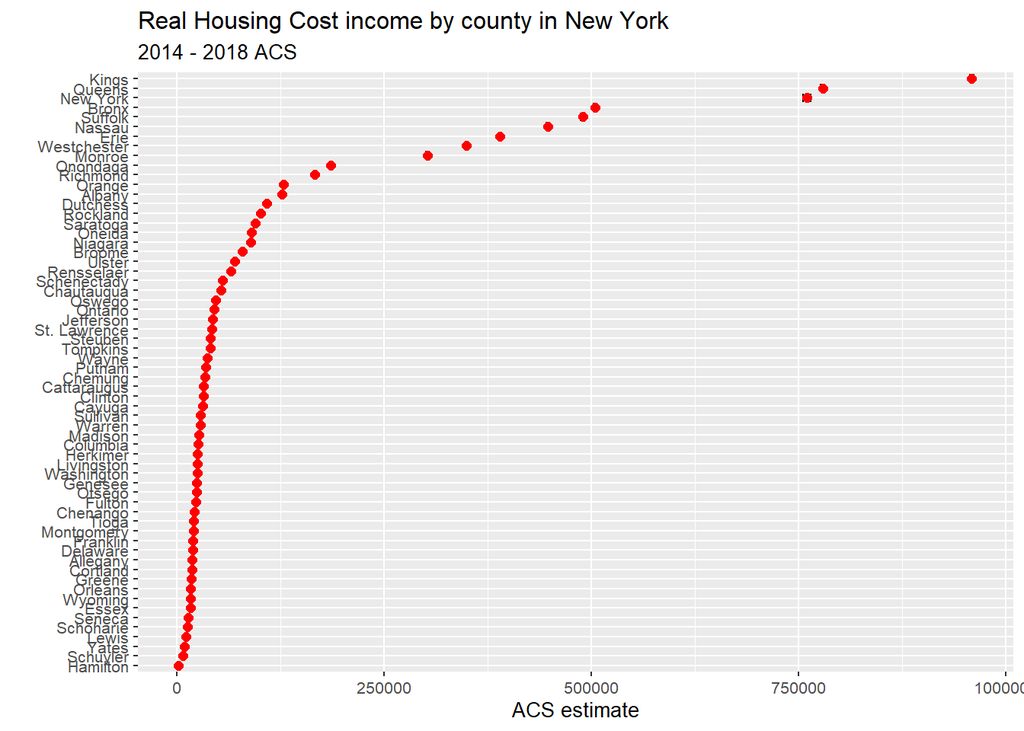

```r
NY <- get_acs(geography = "county", variables = "B25106_001", state = "NY")
NY %>%
mutate(NAME = gsub(" County, New York", "", NAME)) %>%
 ggplot(aes(x = estimate, y = reorder(NAME, estimate))) +
  theme_grey(base_size = 10) +
  geom_errorbarh(aes(xmin = estimate - moe, xmax = estimate + moe)) +
  geom_point(color = "red", size = 2) +
  labs(title = "Real Housing Cost income by county in New York",
       subtitle = "2014 - 2018 ACS",
       y = "",
       x = "ACS estimate")
```

Going down lower into more micro data 3 counties will be picked within the curve namely being Queens, New York City, and Nassau. Picking counties that have larger differences as opposed to 3 counties all bunched in the lower end of the curve will make the factors that effect housing costs more apparent in the later regression.

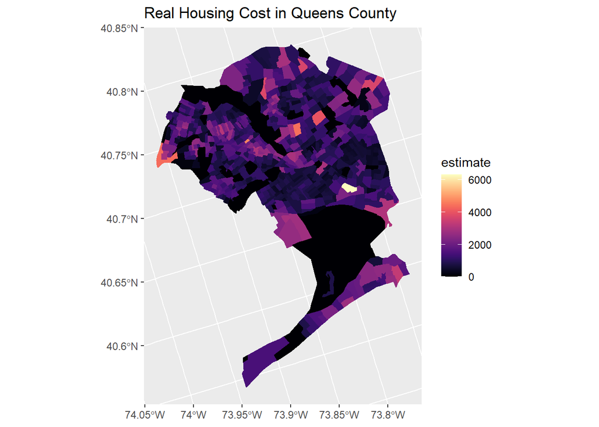

```r
ggplot(Queens, aes(fill = estimate, color = estimate)) +
  geom_sf() +
  labs(title = "Real Housing Cost in Queens County") +
  coord_sf(crs = 26914) +
  scale_fill_viridis(option = "magma") +
  scale_color_viridis(option = "magma")
```

```r
Newyork <- get_acs(geography = "tract", variables = "B25106_001",
                state = "NY", county = "New York", geometry = TRUE)
```

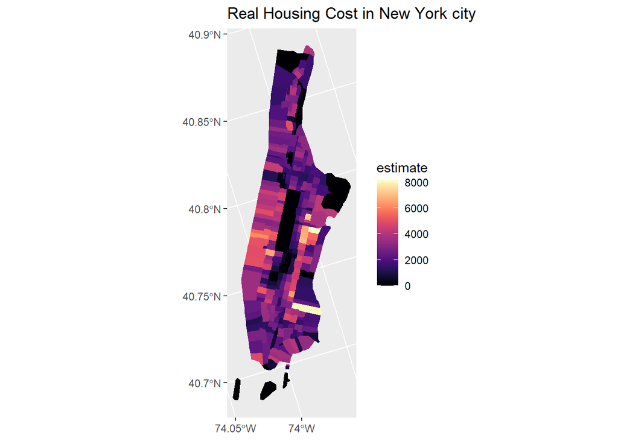

```r
ggplot(Newyork, aes(fill = estimate, color = estimate)) +
  geom_sf() +
  labs(title = "Real Housing Cost in New York city") +
  coord_sf(crs = 26914) +
  scale_fill_viridis(option = "magma") +
  scale_color_viridis(option = "magma")
```

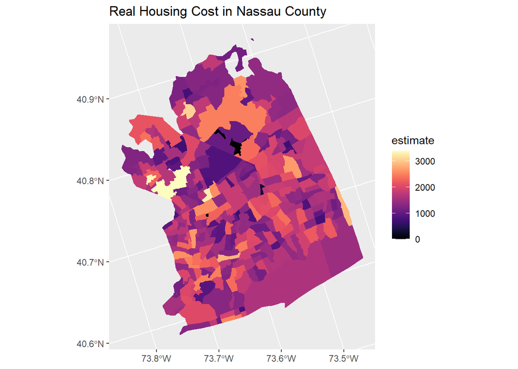

```r
Nassau <- get_acs(geography = "tract", variables = "B25106_001",
                state = "NY", county = "Nassau", geometry = TRUE)
ggplot(Nassau, aes(fill = estimate, color = estimate)) +
  geom_sf() +
  labs(title = "Real Housing Cost in Nassau County") +
  coord_sf(crs = 26914) +
  scale_fill_viridis(option = "magma") +
  scale_color_viridis(option = "magma")
```

The target of the following regression is to look at a few key factors such as population and mobilty. population in regards to density and mobility in regards to willingness to move houses which is measured by someone moving in the past 12 months. From there the regression focuses mainly on transportation. Types of transportation, walking, biking, cars, and public transit. Then on the time requirements in the overall transportation.

Finally poverty level is also included to see if there are imbalances between socioeconomic classes with regards to real housing costs.

poverty under 1 = B05010_002 1-2 = B05010_010 over 2 = B05010_018

```r
town_costs <- get_acs(geography = "tract",
                     variables =  c(HousingCost = "B25106_001", PovUnderOne = "B05010_002",PovOnetoTwo = "B05010_010",PovTwoPlus = "B05010_018", Totalpop = "B01003_001", Mobility = "B07001_001", Bike = "B08006_014", Walk = "B08006_015", PublicTrans = "B08006_025", Car = "B08006_019", WorkHome = "B08006_017", Ten = "B08134_003", Fifteen = "B08134_004", twenty = "B08134_005", thirty = "B08134_006", thirtyfive = "B08134_007", fortyfive = "B08134_008", sixty = "B08134_009", sixtyplus = "B08134_010"),
                    state = "New York",
                    county = c("Queens", "New York", "Nassau"),
                     output = "wide",


                     )
```

```r
lmliving_cost <- lm(town_costs$HousingCostE ~ town_costs$PovUnderOneE+ town_costs$PovOnetoTwoE+ town_costs$PovTwoPlusE + town_costs$TotalpopE +  town_costs$MobilityE + town_costs$BikeE + town_costs$WalkE + town_costs$PublicTransE + town_costs$CarE + town_costs$WorkHomeE + town_costs$TenE + town_costs$FifteenE + town_costs$twentyE + town_costs$thirtyE + town_costs$thirtyfiveE + town_costs$fortyfiveE + town_costs$sixtyE + town_costs$sixtyplusE)
```

```r
summary(lmliving_cost)
```

```
##
## Call:
## lm(formula = town_costs$HousingCostE ~ town_costs$PovUnderOneE +
##     town_costs$PovOnetoTwoE + town_costs$PovTwoPlusE + town_costs$TotalpopE +
##     town_costs$MobilityE + town_costs$BikeE + town_costs$WalkE +
##     town_costs$PublicTransE + town_costs$CarE + town_costs$WorkHomeE +
##     town_costs$TenE + town_costs$FifteenE + town_costs$twentyE +
##     town_costs$thirtyE + town_costs$thirtyfiveE + town_costs$fortyfiveE +
##     town_costs$sixtyE + town_costs$sixtyplusE)
##
## Residuals:
##      Min       1Q   Median       3Q      Max
## -1256.69  -118.67     2.28   114.78  1235.98
##
## Coefficients:
##                          Estimate Std. Error t value Pr(>|t|)
## (Intercept)             -25.56938   16.12053  -1.586 0.112967
## town_costs$PovUnderOneE  -0.26568    0.07182  -3.699 0.000226 ***
## town_costs$PovOnetoTwoE  -0.74347    0.06988 -10.639  < 2e-16 ***
## town_costs$PovTwoPlusE   -0.24078    0.04278  -5.628 2.26e-08 ***
## town_costs$TotalpopE      0.65917    0.18942   3.480 0.000519 ***
## town_costs$MobilityE     -0.25932    0.18903  -1.372 0.170355
## town_costs$BikeE          0.39652    0.21410   1.852 0.064263 .
## town_costs$WalkE         -0.10377    0.05547  -1.871 0.061624 .
## town_costs$PublicTransE  -0.53438    0.06115  -8.739  < 2e-16 ***
## town_costs$CarE          -0.77641    0.06245 -12.432  < 2e-16 ***
## town_costs$WorkHomeE      0.54599    0.10938   4.992 6.85e-07 ***
## town_costs$TenE           0.28469    0.11194   2.543 0.011108 *
## town_costs$FifteenE       0.33955    0.09536   3.561 0.000384 ***
## town_costs$twentyE        0.64990    0.07224   8.996  < 2e-16 ***
## town_costs$thirtyE        0.92129    0.11175   8.244 4.26e-16 ***
## town_costs$thirtyfiveE    0.25353    0.06466   3.921 9.31e-05 ***
## town_costs$fortyfiveE     0.40684    0.07956   5.114 3.66e-07 ***
## town_costs$sixtyE         0.45253    0.06897   6.561 7.86e-11 ***
## town_costs$sixtyplusE     0.19804    0.05402   3.666 0.000257 ***
## ---
## Signif. codes:  0 '***' 0.001 '**' 0.01 '*' 0.05 '.' 0.1 ' ' 1
##
## Residual standard error: 267.3 on 1222 degrees of freedom
## Multiple R-squared:  0.9458, Adjusted R-squared:  0.945
## F-statistic:  1184 on 18 and 1222 DF,  p-value: < 2.2e-16
```

Looking at the two over arching variables poulation and mobility, population causes an increase in the cost of housing which is to be expected. higher populated areas have higher demand for housing and land is a fixed amount. This effect might be higher in a area that were selected due to the areas all being near water. Water adjacent geographic areas limit the expansion of building causing a limited supply to housing. Mobility is statistically insignificant so can not be used as an explanitory variable.

Lastly tying this regression back into the effects of real housing costs across different socioeconomic levels lets look at poverty levels. These are the ratio of income to poverty level under 1, beween 1 and 1.9, and over 2. The poverty levels all have a decreasing effect on real housing costs. Each tier has a different level of effect. between 1 and 1.9 having the largets effectt, then under 1, and finally 2 and over. This trend continuing the higher the income level the higher the cost of real housing although it is clearly not linear. The current real cost of housing is effecting individuals below and slightly above the poverty line less then more wealthy individuals. Whether this is due to public policy is an area that requires further analysis.

Whats clear from this analysis is that transit in general is a factor on the real cost of housing and access to public transit helps midigate this pressure on individuals. Also how this the real cost of housing is effect by socioeconomic status is seen at least somewhat progressive. Meaning there is less of a burden on the lower end.

Further analysis is recommended that could further this project. frist, whether cars over all impact on real income is positive or negative because it does bring down the real housing costs but it is a large cost unto its self. secondly, the effect of public policy on public transit to drive more equitable housing. Lastly, further anaylsis of increasing real housing costs across socioeconomic tiers.